# Cyclistic Bike-Share Analysis

Nataliia Poladova

2025-01-21

## **Cyclistic Bike-Share Analysis Case Study**

### **1. Introduction**

Cyclistic is a fictional bike-share company based in Chicago, offering a range of bicycles to residents and tourists. The goal of this analysis is to provide insights that will help convert casual riders into annual members by understanding their usage patterns. About the company In 2016, Cyclistic launched a successful bike-share offering. Since then, the program has grown to a fleet of 5,824 bicycles that are geotracked and locked into a network of 692 stations across Chicago. The bikes can be unlocked from one station and returned to any other station in the system anytime.

### **2. Business Task**

The primary business goal is to analyze historical bike trip data to understand:

1. How do annual members and casual riders use Cyclistic bikes differently?
2. Why would casual riders buy Cyclistic annual memberships?
3. How can Cyclistic use digital media to influence casual riders to become members?

**Deliverables:**  
- A clear statement of the business task.  
- Description of data sources used.  
- Documentation of data cleaning and transformation.  
- Summary of findings with supporting visualizations.  
- Key recommendations based on insights.

### **3. Tools and Packages**

The following tools and packages will be used for data analysis:

- **R and RStudio**: For data processing, visualization, and reporting.
- **Tidyverse**: A collection of R packages for data manipulation and visualization.
- **Lubridate**: For date and time manipulation.
- **ggplot2**: For creating visualizations.
- **Tableau**: For creating visualizations.

### **4. Data Source**

The dataset used for this analysis includes the past 12 months of Cyclistic trip data, publicly available at:  
[Divvy Trip Data](https://divvy-tripdata.s3.amazonaws.com/index.html)

#### **Key details:**

1. The data includes bike trips from casual users and annual members.
2. Personally identifiable information (PII) has been removed for privacy compliance.
3. Data is provided under the [Divvy Data License Agreement](https://www.divvybikes.com/data-license-agreement).

### **Let’s Get Started**

To kick off our project, let’s begin by loading the necessary data. This step ensures we have all the information we need to analyze Cyclistic’s bike-share usage patterns effectively.

```r
# Dynamically load all CSV files from the directory
file_paths <- list.files("C:/Users/IntelliBoard/Cyclistic/trip12month/", full.names = TRUE, pattern = "*.csv")
data_trip_year <- purrr::map_df(file_paths, read_csv)

# Check the total rows in the combined dataset
cat("Total rows after merging:", nrow(data_trip_year), "\n")
```

```
## Total rows after merging: 5860568
```

```r
# Check the structure of the combined data
str(data_trip_year)
```

```
## spc_tbl_ [5,860,568 × 13] (S3: spec_tbl_df/tbl_df/tbl/data.frame)
##  $ ride_id           : chr [1:5860568] "C1D650626C8C899A" "EECD38BDB25BFCB0" "F4A9CE78061F17F7" "0A0D9E15EE50B171" ...
##  $ rideable_type     : chr [1:5860568] "electric_bike" "electric_bike" "electric_bike" "classic_bike" ...
##  $ started_at        : POSIXct[1:5860568], format: "2024-01-12 15:30:27" "2024-01-08 15:45:46" ...
##  $ ended_at          : POSIXct[1:5860568], format: "2024-01-12 15:37:59" "2024-01-08 15:52:59" ...
##  $ start_station_name: chr [1:5860568] "Wells St & Elm St" "Wells St & Elm St" "Wells St & Elm St" "Wells St & Randolph St" ...
##  $ start_station_id  : chr [1:5860568] "KA1504000135" "KA1504000135" "KA1504000135" "TA1305000030" ...
##  $ end_station_name  : chr [1:5860568] "Kingsbury St & Kinzie St" "Kingsbury St & Kinzie St" "Kingsbury St & Kinzie St" "Larrabee St & Webster Ave" ...
##  $ end_station_id    : chr [1:5860568] "KA1503000043" "KA1503000043" "KA1503000043" "13193" ...
##  $ start_lat         : num [1:5860568] 41.9 41.9 41.9 41.9 41.9 ...
##  $ start_lng         : num [1:5860568] -87.6 -87.6 -87.6 -87.6 -87.7 ...
##  $ end_lat           : num [1:5860568] 41.9 41.9 41.9 41.9 41.9 ...
##  $ end_lng           : num [1:5860568] -87.6 -87.6 -87.6 -87.6 -87.6 ...
##  $ member_casual     : chr [1:5860568] "member" "member" "member" "member" ...
##  - attr(*, "spec")=
##   .. cols(
##   ..   ride_id = col_character(),
##   ..   rideable_type = col_character(),
##   ..   started_at = col_datetime(format = ""),
##   ..   ended_at = col_datetime(format = ""),
##   ..   start_station_name = col_character(),
##   ..   start_station_id = col_character(),
##   ..   end_station_name = col_character(),
##   ..   end_station_id = col_character(),
##   ..   start_lat = col_double(),
##   ..   start_lng = col_double(),
##   ..   end_lat = col_double(),
##   ..   end_lng = col_double(),
##   ..   member_casual = col_character()
##   .. )
##  - attr(*, "problems")=<externalptr>
```

#### **Data Cleaning and Preparation**

The first step is to clean the combined dataset to ensure it is ready for analysis. This includes removing duplicates, checking date formats, and handling missing or invalid data.

```r
# Remove duplicate rows based only on 'ride_id' while keeping all other columns
data_trip_year_clean <- data_trip_year %>%
  distinct(ride_id, .keep_all = TRUE)

# Calculate the number of rows removed
rows_removed <- nrow(data_trip_year) - nrow(data_trip_year_clean)

# Print the results
cat("Original number of rows:", nrow(data_trip_year), "\n")
```

```
## Original number of rows: 5860568
```

```r
cat("Number of rows after removing duplicates:", nrow(data_trip_year_clean), "\n")
```

```
## Number of rows after removing duplicates: 5860357
```

```r
cat("Number of duplicate rows removed:", rows_removed, "\n")
```

```
## Number of duplicate rows removed: 211
```

**Let’s check date format**

```r
# Convert 'started_at' and 'ended_at' to POSIXct format if needed
data_trip_year <- data_trip_year %>%
  mutate(
    started_at = as.POSIXct(started_at, format = "%Y-%m-%d %H:%M:%S", tz = "UTC"),
    ended_at = as.POSIXct(ended_at, format = "%Y-%m-%d %H:%M:%S", tz = "UTC")
  )
cat("Class of 'started_at':", class(data_trip_year$started_at), "\n")
```

```
## Class of 'started_at': POSIXct POSIXt
```

```r
cat("Class of 'ended_at':", class(data_trip_year$ended_at), "\n")
```

```
## Class of 'ended_at': POSIXct POSIXt
```

**Let’s check missing values**

```r
# Check for missing values (NA) in the entire dataset
na_summary <- colSums(is.na(data_trip_year))

# Display columns with missing values
na_summary <- na_summary[na_summary > 0]  # Keep only columns with NA
na_summary
```

```
## start_station_name   start_station_id   end_station_name     end_station_id
##            1073951            1073951            1104653            1104653
##            end_lat            end_lng
##               7232               7232
```

**Handling Missing Values**

During the data exploration, it was observed that the columns `start_station_name`, `start_station_id`, `end_station_name`, and `end_station_id` contain a significant number of missing values (`NA`). Since these columns are not critical for answering the primary business question, they will not be fully analyzed at this stage. However, I noticed an anomaly: a notable number of trips have an `end_station_name` but lack a `start_station_name`. This indicates trips that appear to have ended without a recorded start.

```r
# Unique start and end stations
unique_start <- unique(data_trip_year_clean$start_station_id)
unique_end <- unique(data_trip_year_clean$end_station_id)

# Identify stations that appear only as end stations (never used as a start station)
missing_in_start <- setdiff(unique_end, unique_start)

# Output the number of such stations
cat("Stations that appear only as end stations:", length(missing_in_start), "\n")
```

```
## Stations that appear only as end stations: 11
```

**Unique End-Only Stations: Possible Explanations**

1. **Return-only stations** – Some locations may be designated solely for bike returns, not departures.
2. **Data errors** – Missing start station data could result from system glitches or incorrect logging.
3. **Temporary stations** – Certain drop-off points might be active only during specific events or seasons.

**Why Keep Rows with Missing Station Data?**  
- They still provide useful timestamps (`started_at`, `ended_at`) for trip analysis.  
- Missing values may indicate improper bike docking, offering insights into user behavior.

**Conclusion** While missing station data was retained for this analysis, a deeper investigation could reveal anomalies or unique patterns. For now, these trips remain part of the dataset to ensure comprehensive insights.

##### **Next Step:**

However, I explored rows with missing values in station-related columns to check if they could provide useful insights. During this analysis, I found negative trip durations in the started_at and ended_at columns, indicating system errors. This discovery led me to filter out all rows with negative durations across the entire dataset to ensure data integrity.

```r
# Filter rows where station-related columns have NA values
rows_with_na <- data_trip_year %>%
  filter(is.na(start_station_name) | is.na(end_station_name))

# Calculate summary statistics for trip duration in rows with NA values
rows_with_na %>%
  mutate(ride_length = as.numeric(difftime(ended_at, started_at, units = "mins"))) %>%
  summarise(
    min_duration = min(ride_length, na.rm = TRUE),
    mean_duration = mean(ride_length, na.rm = TRUE),
    max_duration = max(ride_length, na.rm = TRUE),
    total_trips = n()
  ) %>%
  filter(!is.na(min_duration))  # Ensure no errors from NA
```

```
## # A tibble: 1 × 4
##   min_duration mean_duration max_duration total_trips
##          <dbl>         <dbl>        <dbl>       <int>
## 1       -2748.          19.0        1560.     1652259
```

I created a duration column and removed all rows where the trip duration was negative or shorter than 60 seconds. This ensures that only valid trips remain for analysis

```r
# Create 'duration' column and save to a new dataset
data_trip_year_clean <- data_trip_year %>%
  mutate(duration = as.numeric(difftime(ended_at, started_at, units = "secs"))) %>%
  filter(duration >= 60 & duration > 0)  # Remove trips shorter than 60 seconds and negative durations

# Verify the cleaned dataset
summary(data_trip_year_clean$duration)
```

```
##    Min. 1st Qu.  Median    Mean 3rd Qu.    Max.
##    60.0   347.3   596.7  1062.3  1051.6 93596.0
```

##### **Handling Rows with Missing Station Data**

During the data cleaning process, I decided to explore rows where station-related columns (`start_station_name`, `end_station_name`) contain `NA` values. Specifically, I wanted to check two aspects:

1. **Presence of data in other columns except time-columns**: Determine if these rows have meaningful information in other attributes.
2. **Average duration of trips with only time data**: Analyze the average trip duration for records where only `started_at` and `ended_at` are filled, while other attributes are missing.

```r
# Filter rows where station columns are NA
rows_with_na_stations <- data_trip_year %>%
  filter(is.na(start_station_name) & is.na(end_station_name))

# Check if other columns are filled
rows_with_na_stations_summary <- rows_with_na_stations %>%
  summarise(across(everything(), ~ sum(!is.na(.))))  # Count non-NA values in each column

print(rows_with_na_stations_summary)
```

```
## # A tibble: 1 × 13
##   ride_id rideable_type started_at ended_at start_station_name start_station_id
##     <int>         <int>      <int>    <int>              <int>            <int>
## 1  526345        526345     526345   526345                  0                0
## # ℹ 7 more variables: end_station_name <int>, end_station_id <int>,
## #   start_lat <int>, start_lng <int>, end_lat <int>, end_lng <int>,
## #   member_casual <int>
```

**Insights**

1. **Key Finding**:  
   All rows with valid `started_at` and `ended_at` times also contain non-missing values in essential columns like `ride_id` and `rideable_type`. This indicates that these rows represent actual trips despite missing station information.
2. **Decision**:
   - Since these records have valid trip identifiers and bike types, and their durations are critical for the analysis, I decided not to exclude these rows. This ensures that we maintain a comprehensive dataset for analyzing user behavior and trip patterns.
   - The second planned step, analyzing the average duration of trips with only time data, was deemed unnecessary because all rows with time data included sufficient additional attributes to confirm their validity.

##### **Analyzing Start Points of Trips: Identifying Anomalies**

During the initial analysis of trip start locations, I observed that some points appear in the water. To investigate this further, I visualized all the starting locations on a map.

**Visualization:** The map below highlights starting points of trips, including those that fall in Lake Michigan. This raises questions about the validity of these points and the potential reasons for their occurrence.

[figure not shown]

**Investigating Relation to Missing Station Data**

To understand if the points in the water correspond to rows with missing station information (`start_station_name`, `end_station_name`), I isolated rows with missing station names and visualized their start locations on a map.

**Visualization:**

The following map shows only the points associated with missing station names. The goal was to determine if these missing values correlate with the out-of-water points.

```r
# Filter rows where station names are NA
na_station_points <- data_trip_year_clean %>%
    filter(is.na(start_station_name) | is.na(end_station_name))

# Check the number of such points
print(paste("Number of rows with NA in station names:", nrow(na_station_points)))
```

```
## [1] "Number of rows with NA in station names: 1560378"
```

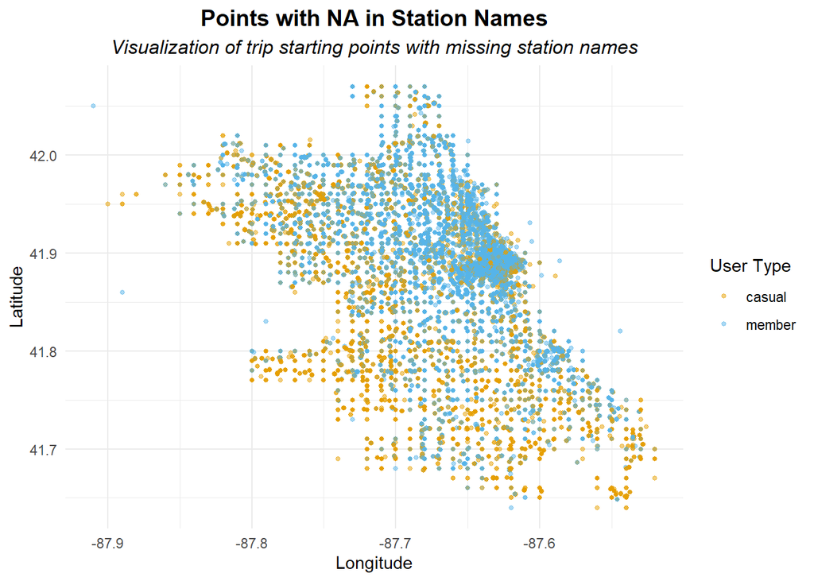

```r
# Visualize these points
ggplot(na_station_points, aes(x = start_lng, y = start_lat, color = member_casual)) +
    geom_point(alpha = 0.5, size = 1) +
    scale_color_manual(values = c("casual" = "#E69F00", "member" = "#56B4E9"), name = "User Type") +
    labs(
        title = "Points with NA in Station Names",
        subtitle = "Visualization of trip starting points with missing station names",
        x = "Longitude",
        y = "Latitude"
    ) +
    theme_minimal() +
    theme(
        plot.title = element_text(size = 14, face = "bold", hjust = 0.5),
        plot.subtitle = element_text(size = 12, hjust = 0.5, face = "italic")
    )
```

**Insights on Missing Data Correlation**

The distribution of trips with missing station names is spread throughout the city, rather than clustering near water or outside Chicago’s boundaries. This suggests that missing station data is unrelated to geographical anomalies.

**Decision**  
Since these trips are valid (`ride_id`, `rideable_type`, and `duration` confirm their integrity), they will be retained for further analysis. Out-of-boundary points will also remain for now, pending further validation.

**Challenges with Geographical Boundaries**  
Excluding all trips outside Chicago might remove water points, but the city’s irregular lakefront shape complicates this approach. Latitude and longitude alone cannot define boundaries without precise geographic data. Additionally, some areas of Chicago extend into water, making strict filtering impractical.

**Conclusion**  
For now, water points remain in the dataset as they form a small subset and do not significantly impact the analysis. Further filtering can be reconsidered if needed.

#### **Visualizing the Distribution of Trip Durations**

While cleaning the data, I considered whether additional filtering was necessary. To decide, I created an intermediate visualization to examine the distribution of trip durations. The goal was to identify the concentration of typical trips and determine if exceptionally long trips might need to be removed.

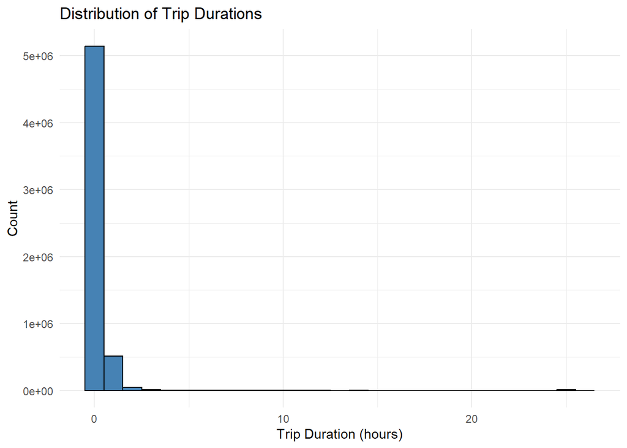

```r
# Visualize the distribution of trip durations (convert seconds to hours)
library(ggplot2)

ggplot(data_trip_year_clean, aes(x = duration / 3600)) +  # Convert seconds to hours
  geom_histogram(binwidth = 1, fill = "steelblue", color = "black") +
  labs(
    title = "Distribution of Trip Durations",
    x = "Trip Duration (hours)",
    y = "Count"
  ) +
  theme_minimal()
```

```r
# Filter long trips (> 10 hours) and calculate percentage
long_trips <- data_trip_year_clean %>%
  filter(duration > 36000)  # 36000 seconds = 10 hours

# Calculate the percentage of long trips
long_trip_percentage <- nrow(long_trips) / nrow(data_trip_year_clean) * 100
long_trip_percentage
```

```
## [1] 0.1870297
```

After analyzing the distribution of trip durations, it was observed that trips lasting more than 10 hours account for only **0.19%** of the dataset. These trips are rare but plausible, as they may reflect delays in returning bikes rather than errors.

**Conclusion:** Given their minimal percentage and potential relevance to user behavior, these long trips will be retained in the dataset to ensure a comprehensive analysis.

##### **Data Cleaning Summary**

**Steps Taken:** 1. Created a `duration` column by calculating the difference between `ended_at` and `started_at`.  
2. Removed negative durations and trips shorter than 60 seconds.  
3. Retained long trips (over 10 hours) as they accounted for only **0.19%** of the data and could reflect user behavior.  
4. Kept columns with missing values, to ensure inclusivity and maximize insights..

**Anomalies Observed:**  
- Negative durations caused by system errors.  
- Extremely short trips likely due to user or system errors.  
- Long trips reflecting possible delays in returning bikes.  
- Trips starting or ending in water, indicating possible GPS inaccuracies or data entry errors.

The cleaned dataset `data_trip_year_clean` is now ready for further analysis.

#### **Visualizing Usage Patterns**

To understand the differences in how casual and annual members use Cyclistic bikes, we will create visualizations to highlight key patterns. These visualizations will focus on:

- **Trip durations**: Comparing how long casual and member users typically ride.
- **Weekly usage**: Examining usage patterns across days of the week.
- **Hourly activity**: Identifying differences in bike usage throughout the day.
- **Average trip duration**: Highlighting differences in the average trip length between user types.
- **Annual trends**: Exploring seasonal and monthly patterns to identify peak and off-peak periods for both casual and member users.
- **Bike type preferences**: Analyzing whether casual or member users prefer classic bikes, electric bikes, or scooters.
- **Geographical analysis**: Mapping trip start and end locations to uncover usage trends in different areas of Chicago, including hotspots and underutilized regions.

These insights will help identify behavioral differences between the two user groups and support data-driven recommendations to increase membership conversions and optimize bike availability.

##### **Distribution of Trip Durations**

The first visualization will examine the distribution of trip durations for casual and member users. This will help us understand how long users typically ride and identify any notable differences between the two groups.

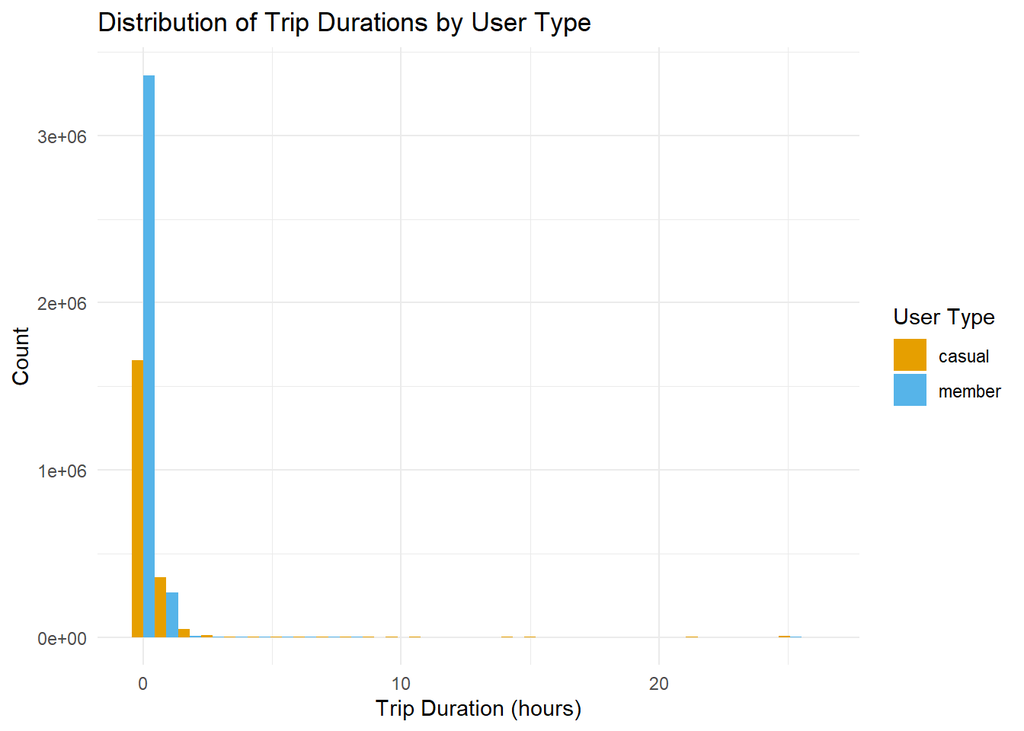

```r
# Create a histogram of trip durations in hours by user type
ggplot(data_trip_year_clean, aes(x = duration / 3600, fill = member_casual)) +  # Duration in hours
  geom_histogram(position = "dodge", bins = 30) +  # Dodge for side-by-side comparison
  labs(
    title = "Distribution of Trip Durations by User Type",
    x = "Trip Duration (hours)",
    y = "Count"
  ) +
  scale_fill_manual(values = c("casual" = "#E69F00", "member" = "#56B4E9"), name = "User Type") +
  theme_minimal()
```

**Findings** - The majority of trips are **very short**, typically lasting less than an hour. - **Members (blue)** tend to have significantly more trips compared to casual users. - **Casual users (orange)** exhibit a slightly wider spread in trip durations, suggesting that they may take longer rides more frequently than members. - There are very few trips that extend beyond a few hours, indicating that long-duration trips are uncommon.

This analysis suggests that members primarily use the bike-sharing service for **short, frequent trips**, while casual users may have more variability in their trip durations.

Let’s see a proportion of total trip durations (in hours) between “casual” and “member” users.

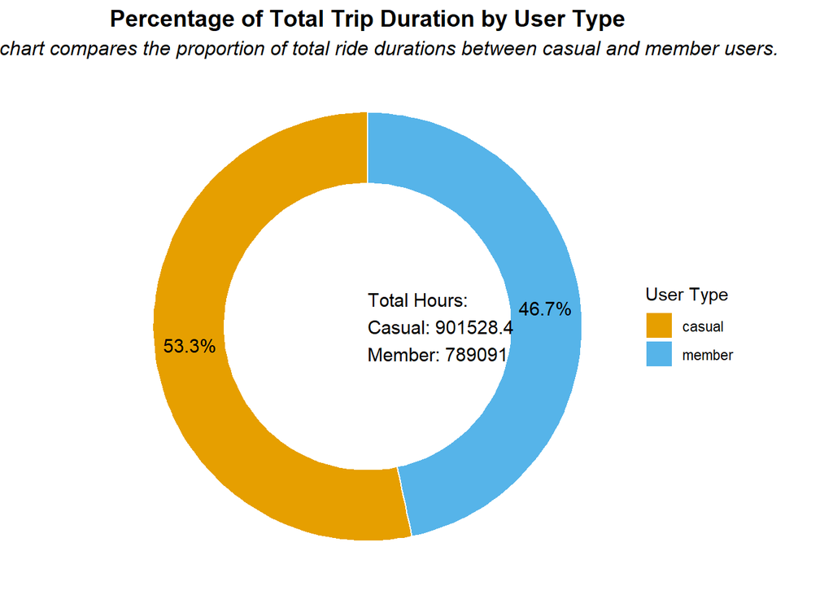

```r
# Step 1: Calculate total duration by user type
summary_table <- data_trip_year_clean %>%
  group_by(member_casual) %>%
  summarise(total_duration_hours = sum(duration / 3600)) %>%
  mutate(percentage = total_duration_hours / sum(total_duration_hours) * 100)

# Step 2: Extract values for the annotation
total_casual <- summary_table %>% filter(member_casual == "casual") %>% pull(total_duration_hours)
total_member <- summary_table %>% filter(member_casual == "member") %>% pull(total_duration_hours)

# Step 3: Create the pie chart
ggplot(summary_table, aes(x = "", y = total_duration_hours, fill = member_casual)) +
  geom_bar(stat = "identity", width = 1, color = "white") +
  coord_polar("y") +
  labs(
    title = "Percentage of Total Trip Duration by User Type",
    subtitle = "This chart compares the proportion of total ride durations between casual and member users.",
    fill = "User Type"
  ) +
  geom_text(aes(label = paste0(round(percentage, 1), "%")),
            position = position_stack(vjust = 0.5), color = "black", size = 4) +
  annotate("text", x = -1.5, y = 1.5,  # Adjust position to top-left
           label = paste0("Total Hours:\nCasual: ", round(total_casual, 1),
                          "\nMember: ", round(total_member, 1)),
           size = 4, hjust = 0) +  # Align text to the left
  scale_fill_manual(
    values = c("casual" = "#E69F00", "member" = "#56B4E9"),
    name = "User Type"
  ) +
  theme_void() +
  theme(
    plot.title = element_text(size = 14, face = "bold", hjust = 0.5),
    plot.subtitle = element_text(size = 12, hjust = 0.5, face = "italic")
  )
```

**Findings from the Pie Chart Analysis**

1. **Casual users accounted for 53.3% of the total trip duration**, while **members contributed 46.7%**.
2. This chart highlights the overall proportion of time spent on trips by casual and member users but does not provide insights into their average trip durations or trip frequencies. These metrics will be analyzed in the next steps.

#### Average Trips per User Type

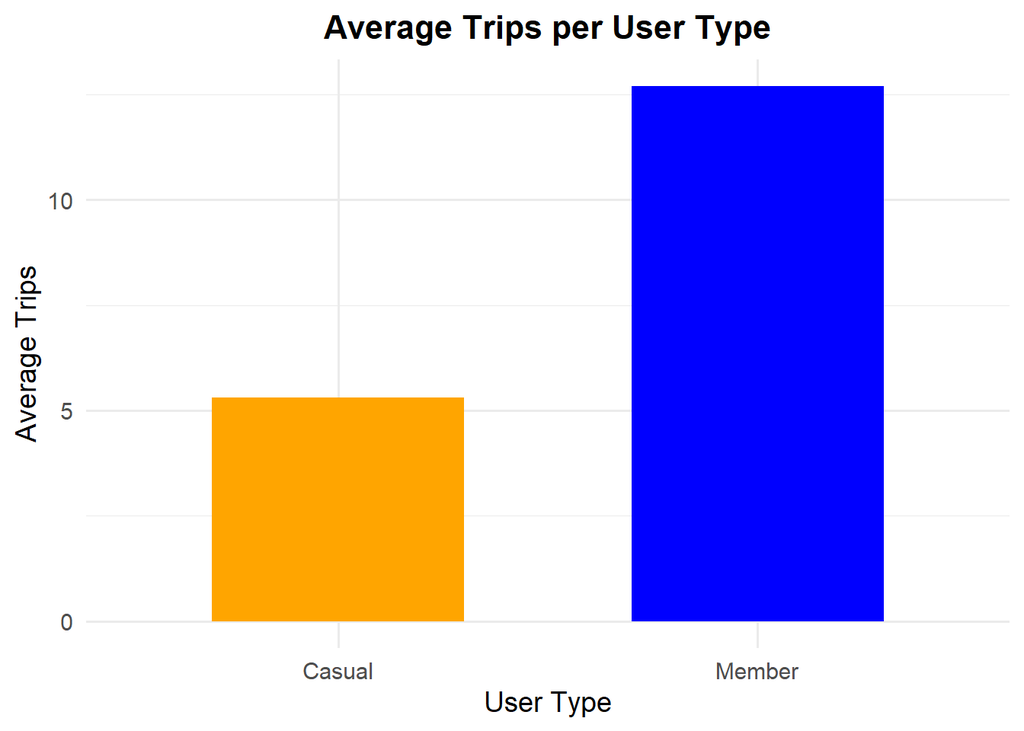

```r
library(ggplot2)

# Example dataset
avg_trips_data <- data.frame(
  user_type = c("Casual", "Member"),
  avg_trips = c(5.3, 12.7)  # Example values
)

# Create the bar plot
ggplot(avg_trips_data, aes(x = user_type, y = avg_trips, fill = user_type)) +
  geom_bar(stat = "identity", width = 0.6) +
  scale_fill_manual(values = c("Casual" = "orange", "Member" = "blue")) +
  labs(title = "Average Trips per User Type",
       x = "User Type",
       y = "Average Trips") +
  theme_minimal(base_size = 14) +
  theme(legend.position = "none",
        plot.title = element_text(size = 16, face = "bold", hjust = 0.5))
```

**Findings**

One potential limitation is that these metrics do not account for **how trips are distributed across different days of the week**. If members and casual riders use the service on different schedules, a direct comparison of total or average trips might be misleading.

To get a clearer picture of user behavior, we will now analyze **trip distribution by day of the week**. This will help us determine whether there are significant differences in when each group is most active.

#### **Analysis of Trip Duration and Total Trips by User Type**

In this section, we analyze two key metrics for casual and member users:  
1. **Average Trip Duration**: How long users typically ride.  
2. **Total Number of Trips**: How frequently users ride.

This analysis helps us understand behavioral differences between the two user groups, providing insights into their usage patterns and preferences. Visualizations will compare these metrics side by side for easier interpretation.

```r
# Calculate the average trip duration (in minutes) and total number of trips for casual and member users
summary_stats <- data_trip_year_clean %>%
  group_by(member_casual) %>%
  summarise(
    average_duration = mean(duration / 60),  # Average trip duration in minutes
    total_trips = n()  # Total number of trips
  )

# Print the summary table
print(summary_stats)
```

```
## # A tibble: 2 × 3
##   member_casual average_duration total_trips
##   <chr>                    <dbl>       <int>
## 1 casual                    25.9     2086305
## 2 member                    13.0     3642733
```

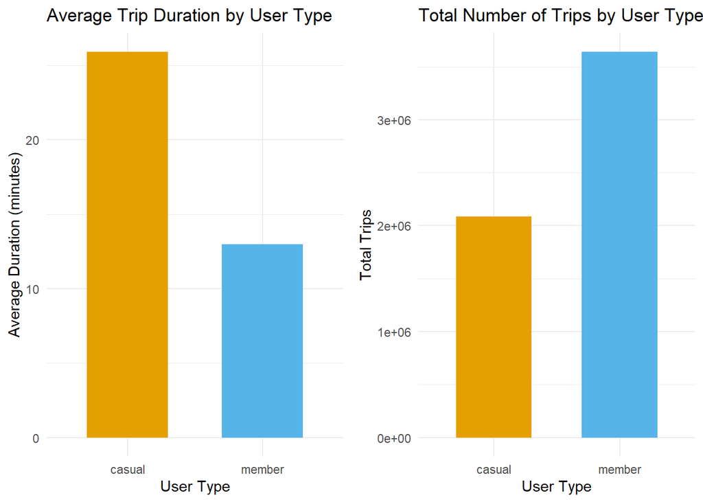

```r
# Visualization: Average trip duration by user type
p_avg_duration <- ggplot(summary_stats, aes(x = member_casual, y = average_duration, fill = member_casual)) +
  geom_bar(stat = "identity", width = 0.6) +
  scale_fill_manual(values = c("casual" = "#E69F00", "member" = "#56B4E9")) +
  labs(
    title = "Average Trip Duration by User Type",
    x = "User Type",
    y = "Average Duration (minutes)"
  ) +
  theme_minimal() +
  theme(legend.position = "none")

# Visualization: Total number of trips by user type
p_total_trips <- ggplot(summary_stats, aes(x = member_casual, y = total_trips, fill = member_casual)) +
  geom_bar(stat = "identity", width = 0.6) +
  scale_fill_manual(values = c("casual" = "#E69F00", "member" = "#56B4E9")) +
  labs(
    title = "Total Number of Trips by User Type",
    x = "User Type",
    y = "Total Trips"
  ) +
  theme_minimal() +
  theme(legend.position = "none")

# Display both plots side by side
grid.arrange(p_avg_duration, p_total_trips, ncol = 2)
```

**Findings**

**Conclusion:** Casual users ride for leisure, while members use bikes more for regular commuting.

#### **Exploring Bike Usage by User Type**

In this section, we will analyze how different types of bikes (e.g., classic, electric, electric_scooter) are used by casual users and members. Understanding these preferences can provide insights into user behavior and help optimize bike availability for each group.

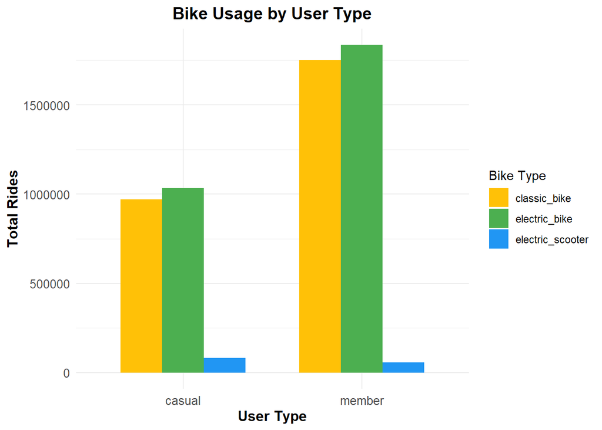

```r
# Group data by user type and bike type
user_bike <- data_trip_year_clean %>%
  group_by(member_casual, rideable_type) %>%
  summarise(total_bike = n(), .groups = "drop") %>%
  mutate(percentage = total_bike / sum(total_bike) * 100)

# Electric bikes
total_electric_bike_casual <- user_bike %>%
  filter(member_casual == "casual", rideable_type == "electric_bike") %>%
  pull(total_bike)

total_electric_bike_member <- user_bike %>%
  filter(member_casual == "member", rideable_type == "electric_bike") %>%
  pull(total_bike)

# Classic bikes
total_classic_bike_casual <- user_bike %>%
  filter(member_casual == "casual", rideable_type == "classic_bike") %>%
  pull(total_bike)

total_classic_bike_member <- user_bike %>%
  filter(member_casual == "member", rideable_type == "classic_bike") %>%
  pull(total_bike)

# Docked bikes
total_docked_bike_casual <- user_bike %>%
  filter(member_casual == "casual", rideable_type == "electric_scooter") %>%
  pull(total_bike)

total_docked_bike_member <- user_bike %>%
  filter(member_casual == "member", rideable_type == "electric_scooter") %>%
  pull(total_bike)

# Stacked Bar Chart to visualize bike usage by user type
ggplot(user_bike, aes(x = member_casual, y = total_bike, fill = rideable_type)) +
  geom_bar(stat = "identity", position = "dodge", width = 0.7) +  # Change position to "stack" for stacked bar chart
  scale_fill_manual(
    values = c("electric_bike" = "#4CAF50",
               "classic_bike" = "#FFC107",
               "electric_scooter" = "#2196F3"),
    name = "Bike Type"
  ) +
  labs(
    title = "Bike Usage by User Type",
    x = "User Type",
    y = "Total Rides",
    fill = "Bike Type"
  ) +
  theme_minimal() +
  theme(
    plot.title = element_text(size = 14, face = "bold", hjust = 0.5),
    axis.title = element_text(size = 12, face = "bold"),
    axis.text = element_text(size = 10)
  )
```

**Findings from Bike Usage Analysis**

1. **Electric bikes** are the most used by both user types, with members showing slightly higher preference.
2. **Classic bikes** rank second in popularity for both groups.
3. **Electric scooters** see minimal usage, indicating they are not a primary mode of transport.

**Conclusion**  
Both casual and member users primarily rely on **electric and classic bikes**, with little variation in preferences. Given the low usage of electric scooters, they may require less operational focus.

#### **Geographical Distribution of Member vs. Casual Trips**

To better understand how **Cyclistic members** and **casual riders** utilize the bike-sharing service, I created heatmaps to compare their starting locations. This visualization highlights key behavioral differences and can help inform targeted marketing and infrastructure planning.

[figure not shown]

**Observations from the Heatmaps**

- **Members’ trips** are **highly concentrated** in the central part of the city, forming a dense cluster. This suggests that members frequently ride in a specific area, likely using the service as part of their daily routine.
- **Casual riders’ trips** are more **spread out**, covering a wider area, particularly along the lakefront and further from the city center. This implies that casual users may ride for leisure rather than for structured, repetitive commuting.
- The overall density of trips is noticeably higher for members, reinforcing that they use the service more regularly.

#### **Analyzing Bike Usage Throughout the Year**

In this section, we explore how casual and member users differ in their bike usage patterns throughout the year. Understanding seasonal trends can provide insights into user behavior and help optimize operations and marketing efforts during peak and off-peak months.

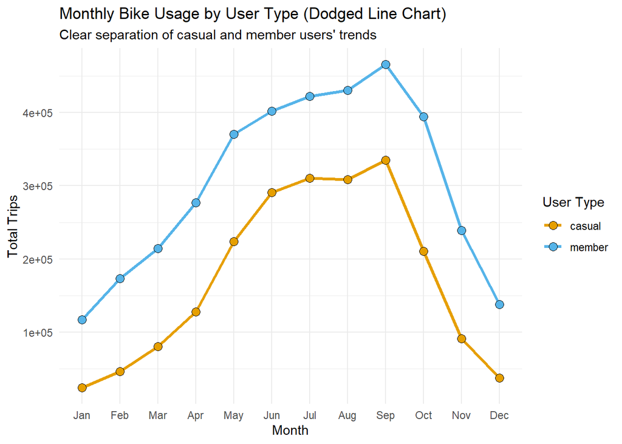

```r
# Add a "month" column to the dataset
data_trip_year_clean <- data_trip_year_clean %>%
  mutate(month = lubridate::month(started_at, label = TRUE, abbr = TRUE))

# Group by month and user type, then count trips
monthly_trips <- data_trip_year_clean %>%
  group_by(month, member_casual) %>%
  summarise(total_trips = n(), .groups = "drop")


# Dodged line chart
ggplot(monthly_trips, aes(x = month, y = total_trips, color = member_casual)) +
    geom_line(aes(group = member_casual), linewidth = 1.2) +
    geom_point(size = 3, shape = 21, aes(fill = member_casual), color = "black") +
    labs(
        title = "Monthly Bike Usage by User Type (Dodged Line Chart)",
        subtitle = "Clear separation of casual and member users' trends",
        x = "Month",
        y = "Total Trips",
        color = "User Type",
        fill = "User Type"
    ) +
    scale_color_manual(values = c("casual" = "#E69F00", "member" = "#56B4E9")) +
    scale_fill_manual(values = c("casual" = "#E69F00", "member" = "#56B4E9")) +
    theme_minimal()
```

**Findings:** Both casual and member users follow very similar seasonal patterns:  
- Usage peaks in the warmer months (July to September).  
- A sharp decline is observed in winter (December to February).

**Conclusion:** This chart confirms that both user groups are influenced by seasonal factors, but it does not reveal significant behavioral differences between them. As such, while the analysis is documented for transparency, it does not directly contribute to actionable insights.

#### **Bike Usage by Day of the Week**

In this section, we analyze how casual and member users differ in their bike usage across the days of the week. This can help identify patterns in behavior, such as preferences for weekdays versus weekends, and guide operational decisions.

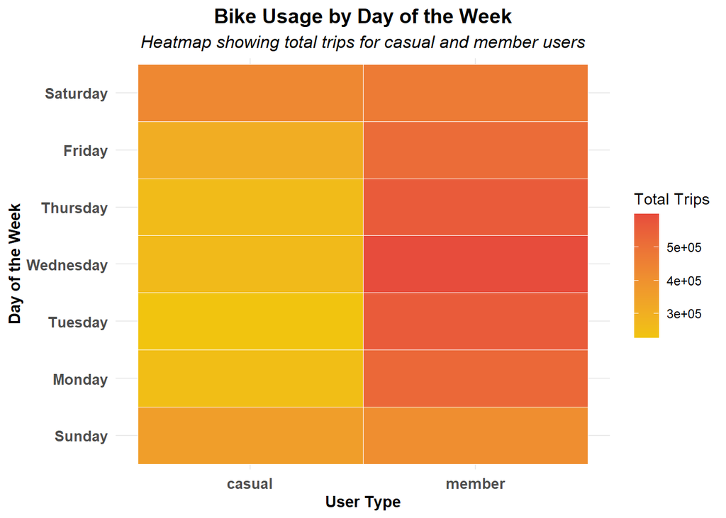

```r
# Add a column with the day of the week
data_trip_year_clean <- data_trip_year_clean %>%
  mutate(day_of_week = wday(started_at, label = TRUE, abbr = FALSE))

# Group the data by day of the week and user type (casual or member)
weekly_trips <- data_trip_year_clean %>%
  group_by(day_of_week, member_casual) %>%
  summarise(total_trips = n(), .groups = "drop")

# Create a heatmap to visualize total trips by day of the week and user type
ggplot(weekly_trips, aes(x = member_casual, y = day_of_week, fill = total_trips)) +
  geom_tile(color = "white") +  # Create heatmap tiles with white borders
  scale_fill_gradient(low = "#F1C40F", high = "#E74C3C", name = "Total Trips") +  # Gradient color for trip density
  labs(
    title = "Bike Usage by Day of the Week",
    subtitle = "Heatmap showing total trips for casual and member users",
    x = "User Type",
    y = "Day of the Week"
  ) +
  theme_minimal() +  # Apply a minimal theme for the plot
  theme(
    plot.title = element_text(size = 14, face = "bold", hjust = 0.5),  # Title formatting
    plot.subtitle = element_text(size = 12, hjust = 0.5, face = "italic"),  # Subtitle formatting
    axis.title = element_text(face = "bold"),  # Bold axis titles
    axis.text.x = element_text(size = 10, face = "bold"),  # Formatting for x-axis labels
    axis.text.y = element_text(size = 10, face = "bold")  # Formatting for y-axis labels
  )
```

**Member Users:**  
- Show steady activity throughout all weekdays, with a slight increase on Wednesday.

**Conclusion:**  
- **Casual users** prefer weekends for recreational use.  
- **Member users** demonstrate consistent usage, indicating a focus on commuting or practical purposes.

#### **Bike Usage by Hour of the Day**

In this analysis, we explore how casual and member users differ in their bike usage throughout the day. Understanding hourly patterns can provide insights into user behavior, such as commuting or leisure activities, and help optimize bike availability during peak hours.

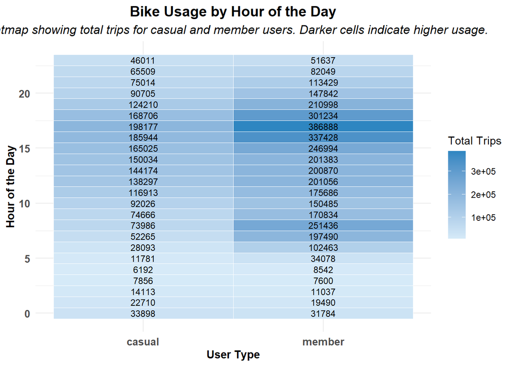

```r
# Add a column for the hour of the trip start time
data_trip_year_clean <- data_trip_year_clean %>%
  mutate(hour = hour(started_at))  # Extract the hour from the start time

# Group data by hour and user type, then count the total trips
hourly_trips <- data_trip_year_clean %>%
  group_by(hour, member_casual) %>%
  summarise(total_trips = n(), .groups = "drop")

# Create a heatmap to visualize hourly bike usage with labels showing trip counts
ggplot(hourly_trips, aes(x = member_casual, y = hour, fill = total_trips)) +
  geom_tile(color = "white") +
  geom_text(aes(label = total_trips), color = "black", size = 3) +  # Add text labels to tiles
  scale_fill_gradient(low = "#D6EAF8", high = "#2E86C1", name = "Total Trips") +
  labs(
    title = "Bike Usage by Hour of the Day",
    subtitle = "Heatmap showing total trips for casual and member users. Darker cells indicate higher usage.",
    x = "User Type",
    y = "Hour of the Day"
  ) +
  theme_minimal() +
  theme(
    plot.title = element_text(size = 14, face = "bold", hjust = 0.5),
    plot.subtitle = element_text(size = 12, hjust = 0.5, face = "italic"),
    axis.title = element_text(face = "bold"),
    axis.text.x = element_text(size = 10, face = "bold"),
    axis.text.y = element_text(size = 10, face = "bold")
  )
```

**Findings:**

**Casual Users:**  
- Peak hours for casual users are **12 PM to 6 PM**, with usage gradually decreasing in the evening.  
- Early morning (before 7 AM) shows minimal activity.

**Member Users:**  
- Members show two distinct peaks: **8 AM** and **4-6 PM**, which align with standard commuting hours.  
- Moderate activity continues into the evening (after 6 PM), unlike casual users.

**Conclusion:** This heatmap highlights distinct time-based behaviors: - **Casual users** prefer midday rides, indicating recreational usage.  
- **Member users** show commuting patterns, peaking during morning and evening rush hours.

#### **Transition to Membership Plans Analysis**

The previous visualizations provided valuable insights into user behavior across different times of the day and days of the week. These patterns revealed key differences between casual and member users, including their preferences for leisure or commuting rides.

To design effective strategies that address both user satisfaction and business goals, it is crucial to balance the benefits for **users** (e.g., personalized plans that fit their needs) with **Cyclistic’s objectives** (e.g., increasing membership conversions and retention).

With this in mind, I hypothesize that introducing tailored membership plans could effectively align user preferences with Cyclistic’s strategic goals. Below, I evaluate the feasibility of implementing such plans and explore their potential benefits.

#### **Final Recommendations**

#### **Membership Plans**

Based on data analysis, introducing tailored membership plans will benefit both users and Cyclistic.

**Proposed Plans:**  
1. **Weekday Plan**: For commuters riding on weekdays.  
2. **Weekend Plan**: For leisure riders on weekends.  
3. **Flexible Plan**: For users with mixed patterns.

**Key Benefits:**  
- **Business:**  
- Increases membership conversions and loyalty.  
- Boosts revenue with tailored offerings.  
- **Users:**  
- Personalized plans meet their specific needs.  
- **Monthly payment options** instead of annual commitments, making it easier for users to subscribe.

**Potential Challenges and Solutions:**  
- **Complexity**: Use clear, simple communication for all plans.  
- **Flexibility**: Allow limited free rides outside the plan:  
- **Weekday Plan Users**: 2 free rides on weekends.  
- **Weekend Plan Users**: 2 free rides on weekdays.  
- **Flexible Plan Users**: Extra 2 free rides for any day.  
- **All Free Rides**: Can be shared with non-members to encourage sign-ups.

**Marketing and Promotions**

**1. Launch New Plans During Holidays**  
- Introduce the updated plans as **exclusive holiday offers**.  
- Promote the plans as a **fresh, exciting way to save money and customize memberships**.

**2. Referral Program**  
- Reward members with free rides for referrals, as outlined above.

**3. Transition Strategy for Existing Members**  
- Current members will remain on their original subscription for **3 months**.  
- Offer them an option to switch to the new plans with **discounted rates**, reflecting the specific day limitations of the new plans.

**4. Email Notification for Casual Users**  
- Send a targeted email campaign to all casual riders, introducing the **exciting membership updates**.  
- Highlight the benefits of switching to tailored plans and the **ease of joining**.

**5. Targeted Campaigns**  
- **Email/SMS Suggestions**:  
- Example: “You recently made 3 weekday rides. Consider our Weekday Plan for more savings!”  
- **Social Media Ads**: Use vibrant visuals and user success stories to build excitement.

##### **Conclusion**

Tailored membership plans and targeted promotions align with user behavior and Cyclistic’s goals. Launching these updates during holidays with referral bonuses, personalized email campaigns for casual users, and options for current members ensures a smooth transition and maximized engagement. This strategy provides mutual benefits, strengthening Cyclistic’s competitive position in the market.

##### **Future Opportunities and Data Gaps**

During the analysis, several **data limitations** were identified. Addressing these gaps could significantly enhance insight depth and accuracy.

**1. Financial Data**  
- **Impact**: Without financial metrics, it is difficult to assess which user group generates more revenue. This limits the ability to prioritize converting casual riders into members based on financial returns.  
- **Use Case**: Metrics like **average revenue per trip/user** could refine strategies for maximizing profitability.

**2. Trip Duration Policy**  
- **Impact**: The dataset lacks information on **maximum trip duration**, making it unclear whether long trips are normal usage or potential misuse.  
- **Use Case**: Knowing this policy would improve recommendations for encouraging casual riders to switch to membership plans.

**3. Lack of User-Specific Data**  
- The absence of **user IDs** prevents tracking individual behavior, limiting insights into **retention rates, repeat usage, and conversion trends**.  
- Missing **demographics (age, gender, ZIP code)** reduces the ability to tailor marketing and membership strategies.

**4. Geographical Boundaries & Anomalies**  
- Some trips **start in Lake Michigan or beyond Chicago’s boundaries**. Without precise **boundary data**, fully cleaning these anomalies is challenging.  
- **Solution**: Including **station boundary data** or validating trip locations against known coordinates could eliminate outliers.

**6. Missing Station Data**  
- Some rows lack **station names**, yet still contain valid trip data (`started_at`, `ended_at`, `member_casual`).  
- These might indicate **dockless trips or system errors**, requiring further investigation to uncover hidden patterns.

#### **Final Thoughts**

To overcome these limitations, incorporating additional data points could greatly enhance Cyclistic’s ability to make data-driven decisions. By including user demographics, revenue metrics, and station-level data, the company could better identify and cater to user needs, optimize operational efficiency, and increase profitability.

While this analysis provided meaningful insights into user behavior and trip patterns, a more comprehensive dataset would unlock deeper opportunities to refine marketing strategies, improve fleet distribution, and design tailored membership plans. Cyclistic’s ongoing commitment to data collection and integration will be crucial for future growth.